# Assessment of Sport Activities - Project Writup

Bijan Ranjbar-Sahraei

17 August, 2015

# Background

Six young health participants were asked to perform one set of 10 repetitions of the Unilateral Dumbbell Biceps Curl (UDBC) in five different fashions: exactly according to the specification (Class A), throwing the elbows to the front (Class B), lifting the dumbbell only halfway (Class C), lowering the dumbbell only halfway (Class D) and throwing the hips to the front (Class E). For further reading we refer to http://groupware.les.inf.puc-rio.br/har

The aim of this project is to train a prediction model which can analyse a UDBC activity using the available features and assess its quality as A, B, C, D or E.

# Understanding the Problem at Hand

In order to understand the problem at hand, we should know what type of activity UDBC is. The following link is a nice totorual for this activity by an expert.

[video not shown]

# Initialization

We set a seed value to make sure the expertiments are repeatable. The packages *lattice*, *ggplot2*, *rattle* and *caret* are needed for this code.

```r
set.seed(3421)
library(lattice)
library(ggplot2)
library(caret)
library(rattle)
```

### Loading data

Before loading data, make sure the working directory is pointing to where the *pml-training.csv* is located. It’s important to translate the *NA* and *#DIV/0!* strings in data import to the *NA* value known by R.

```r
myData <- read.csv("pml-training.csv",
                   header=T,
                   na.strings=c("NA", "#DIV/0!"))
```

Also import the Validation data which consists of 20 sample activites.

```r
validationData <- read.csv("pml-testing.csv")
```

### Seperate the Training and Testing Data

Here we split the *myData* into training and testing sets, where 70% of data is assigned to training set.

```r
inTrain <- createDataPartition(y=myData$classe,
                               p=.7,
                               list=FALSE)
training <- myData[inTrain,]
testing <- myData[-inTrain,]
```

### Exploratory Analytics

```r
useful_features = c("pitch_belt","roll_belt","yaw_belt","total_accel_belt",
                    "gyros_belt_y", "gyros_belt_z","accel_belt_y","magnet_belt_y",
                    "roll_arm","pitch_arm","yaw_arm","avg_roll_arm","accel_arm_x",
                    "avg_roll_dumbbell","gyros_dumbbell_x","magnet_dumbbell_x","accel_dumbbell_y","magnet_dumbbell_z",
                    "roll_forearm","max_roll_forearm","min_pitch_forearm","classe")
```

Correspondingly, I define the *training_useful* and *testing_useful* datasets.

```r
training_useful <- training[,useful_features]
testing_useful <- testing[,useful_features]
```

#### Imputing the NA Values

As many of the values are missing among the useful features, we need to do some impuation. Thus, the following.

```r
preObj <- preProcess(training_useful[,-22], method="knnImpute")
knnTrain <- predict(preObj, training_useful[,-22])
knnTrain$classe <- training_useful$classe
```

In this stage, I use a Decision Tree with aim of finding a smaller subset of informative features. Hopefully, Decision tree will pick a small subset of features for the decision tree.

```r
folds=2
repeats=2
fitControl <- trainControl(method="repeatedcv",number=folds,repeats=repeats,
classProbs=T,
allowParallel=T)

modelFit <- train(classe~., data=knnTrain,
                  method="rpart",metric="ROC",
                  tuneLength=10,
                  trControl=fitControl)
modelFit
```

```
## CART
##
## 13737 samples
##    21 predictor
##     5 classes: 'A', 'B', 'C', 'D', 'E'
##
## No pre-processing
## Resampling: Cross-Validated (2 fold, repeated 2 times)
## Summary of sample sizes: 6868, 6869, 6868, 6869
## Resampling results across tuning parameters:
##
##   cp          Accuracy   Kappa      Accuracy SD  Kappa SD
##   0.01210457  0.6531242  0.5568242  0.03911843   0.05219089
##   0.01230801  0.6531242  0.5568242  0.03911843   0.05219089
##   0.01291832  0.6509405  0.5538318  0.03603682   0.04810314
##   0.01749568  0.6303385  0.5281301  0.04817896   0.06423483
##   0.01953006  0.6041326  0.4949779  0.03706089   0.04807362
##   0.02044553  0.6009298  0.4906050  0.03193939   0.04091465
##   0.02136100  0.5945238  0.4813181  0.03391659   0.04281498
##   0.02492117  0.5223799  0.3706770  0.10694185   0.16704544
##   0.03889737  0.4907872  0.3308009  0.08681144   0.14211672
##   0.11351846  0.3246677  0.0616579  0.04654082   0.07119825
##
## Accuracy was used to select the optimal model using  the largest value.
## The final value used for the model was cp = 0.01230801.
```

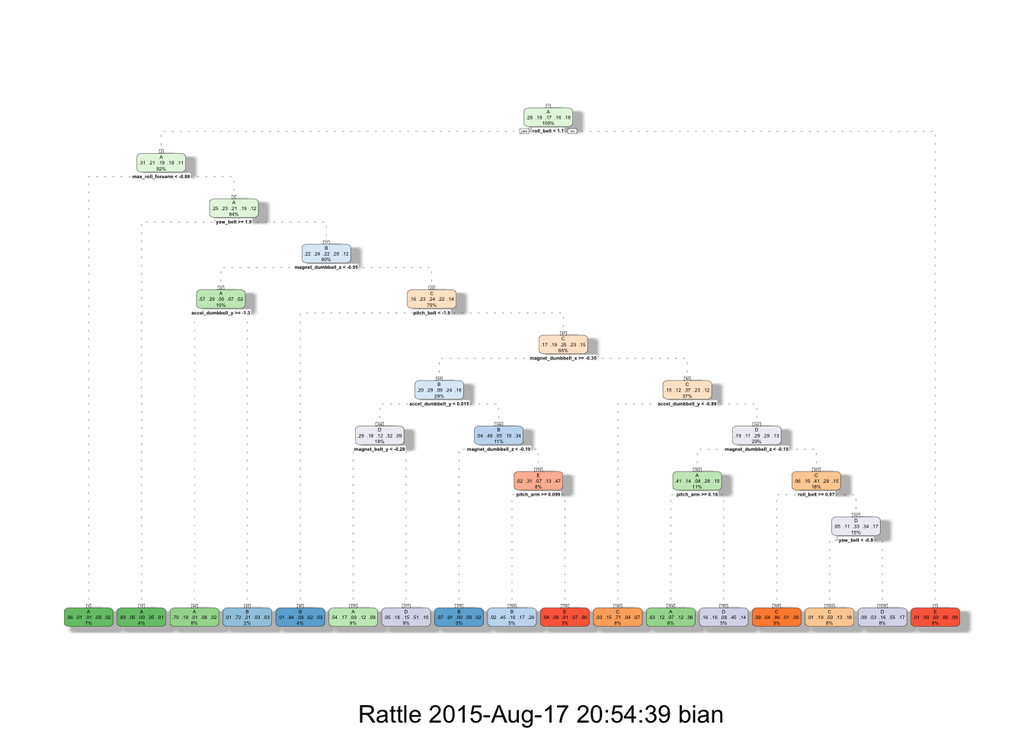

```r
fancyRpartPlot(modelFit$finalModel)
```

### Pronning the Feature Set

Let’s use the results of previous section to redefine the *useful_features* as following.

```r
useful_features = c("roll_belt","max_roll_forearm","yaw_belt","magnet_dumbbell_z",
                    "accel_dumbbell_y", "pitch_belt","accel_belt_y","magnet_dumbbell_x",
                    "magnet_belt_y","magnet_dumbbell_z","classe")

training_useful <- training[,useful_features]
testing_useful <- testing[,useful_features]
```

For the new feature set perform the KNN Imputation.

```r
preObj <- preProcess(training_useful[,-11], method="knnImpute")
knnTrain <- predict(preObj, training_useful[,-11])
knnTrain$classe <- training_useful$classe
```

# Training

Now, we train a Random Forest classifier which we expect to have a very high accuracy.

```r
folds=2
repeats=2
fitControl <- trainControl(method="repeatedcv",number=folds,repeats=repeats,
classProbs=T,
allowParallel=T)

modelFit <- train(classe~., data=knnTrain,
                  method="rf",
                  tuneLength=10,
                  trControl=fitControl)
modelFit$finalModel
```

```
##
## Call:
##  randomForest(x = x, y = y, mtry = param$mtry)
##                Type of random forest: classification
##                      Number of trees: 500
## No. of variables tried at each split: 5
##
##         OOB estimate of  error rate: 4.16%
## Confusion matrix:
##      A    B    C    D    E class.error
## A 3806   39   33   23    5  0.02560164
## B   87 2468   80   22    1  0.07148232
## C   37   45 2266   45    3  0.05425710
## D   26    5   68 2148    5  0.04618117
## E   10   17    8   12 2478  0.01861386
```

Yessss, the results are very promissing, and the model has a high accuracy.

# Testing

Here we use testing dataset to test the model. Before, that we use the knn imputation to replce the not available data values in testing set.

```r
knnTest <- predict(preObj, testing_useful[,-11])
confusionM <- confusionMatrix(predict(modelFit,knnTest), testing_useful$classe)
confusionM
```

```
## Confusion Matrix and Statistics
##
##           Reference
## Prediction    A    B    C    D    E
##          A 1634   31   19   12    5
##          B   16 1076   18    0    4
##          C   16   14  962   26    4
##          D    6   15   26  921    6
##          E    2    3    1    5 1063
##
## Overall Statistics
##
##                Accuracy : 0.9611
##                  95% CI : (0.9558, 0.9659)
##     No Information Rate : 0.2845
##     P-Value [Acc > NIR] : < 2.2e-16
##
##                   Kappa : 0.9508
##  Mcnemar's Test P-Value : 0.003928
##
## Statistics by Class:
##
##                      Class: A Class: B Class: C Class: D Class: E
## Sensitivity            0.9761   0.9447   0.9376   0.9554   0.9824
## Specificity            0.9841   0.9920   0.9877   0.9892   0.9977
## Pos Pred Value         0.9606   0.9659   0.9413   0.9456   0.9898
## Neg Pred Value         0.9904   0.9868   0.9868   0.9912   0.9961
## Prevalence             0.2845   0.1935   0.1743   0.1638   0.1839
## Detection Rate         0.2777   0.1828   0.1635   0.1565   0.1806
## Detection Prevalence   0.2890   0.1893   0.1737   0.1655   0.1825
## Balanced Accuracy      0.9801   0.9683   0.9626   0.9723   0.9901
```

```r
confusionM$table
```

```
##           Reference
## Prediction    A    B    C    D    E
##          A 1634   31   19   12    5
##          B   16 1076   18    0    4
##          C   16   14  962   26    4
##          D    6   15   26  921    6
##          E    2    3    1    5 1063
```

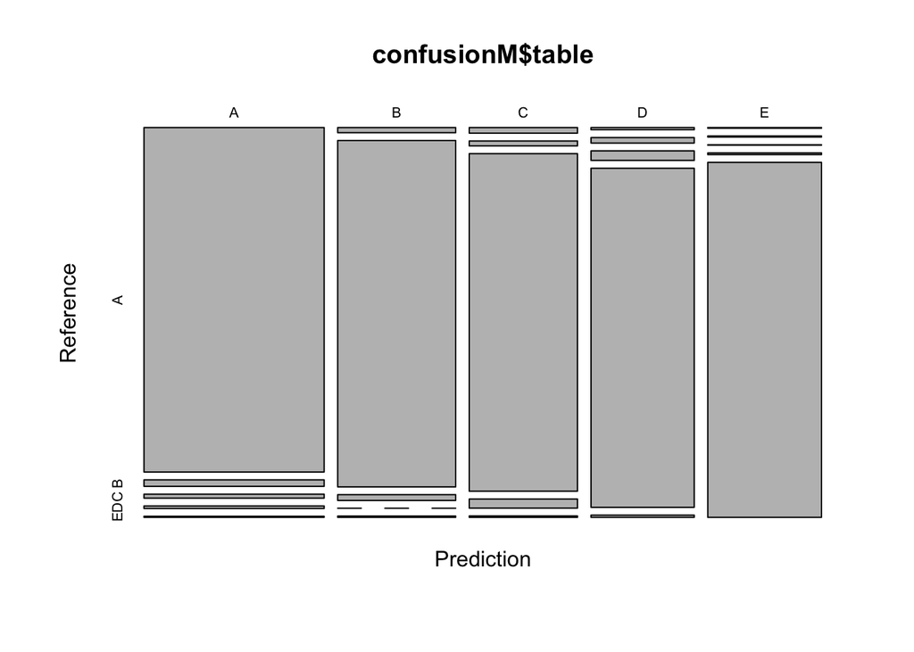

```r
plot(confusionM$table)
```

# Validation

In order to validate the results we predict the validation data provided in Course Project.

```r
validating <- validationData[useful_features[-11]]
knnValid <- predict(preObj, validating[,-11])
answers = predict(modelFit,knnValid)
answers
```

```
##  [1] B A B A A E D B D A B C B A E E A B B B
## Levels: A B C D E
```

### Submiting Answers

To submit the answers, following course puts each response in a file with appropriate name.

```r
pml_write_files = function(x){
  n = length(x)
  for(i in 1:n){
    filename = paste0("problem_id_",i,".txt")
    write.table(x[i],file=filename,quote=FALSE,row.names=FALSE,col.names=FALSE)
  }
}
pml_write_files(answers)
```

# Further Reading

Interested reader can also check the other available writeups on internet.

https://rpubs.com/jocaqui/26619

https://github.com/jeffheaton/jhi-practical-machine-learning/blob/master/PracticalMachineLearning.RMD

http://emres.github.io/practical-ml/

http://rstudio-pubs-static.s3.amazonaws.com/20131_7fca728506724c27bc629081983f0ec2.html